# Analysis on Weight Lifting Exercises Dataset

Guanlin Hou

March 22, 2016

# Background

Using devices such as Jawbone Up, Nike FuelBand, and Fitbit it is now possible to collect a large amount of data about personal activity relatively inexpensively. These type of devices are part of the quantified self movement - a group of enthusiasts who take measurements about themselves regularly to improve their health, to find patterns in their behavior, or because they are tech geeks. One thing that people regularly do is quantify how much of a particular activity they do, but they rarely quantify how well they do it. In this project, my goal will be to use data from accelerometers on the belt, forearm, arm, and dumbell of 6 participants. They were asked to perform barbell lifts correctly and incorrectly in 5 different ways.

## Prepare packages

```r
library(mlbench)
library(reshape2)
library(rpart)
library(rpart.plot)
library(RColorBrewer)
library(randomForest)
library(data.table)
library(rattle)
library(e1071)
library(ggplot2)
library(munsell)
```

## Data Loading

Subset the training dataset to include only the predictors and the outcome variable. Exclude all variables that contain most NA values.

```r
training <- read.csv("C:/Users/rthomas/Desktop/New folder/pml-training.csv", header = T, sep = ",")
testing <- read.csv("C:/Users/rthomas/Desktop/New folder/pml-testing.csv", header = T, sep = ",")
# summary(training)
# summary(testing)
# Remove empty columns
isAnyMissing <- sapply(training, function (x) any(is.na(x) | x == ""))
isPredictor <- !isAnyMissing & grepl("belt|[^(fore)]arm|dumbbell|forearm", names(isAnyMissing))
predCandidates <- names(isAnyMissing)[isPredictor]
predCandidates
```

```
##  [1] "roll_belt"            "pitch_belt"           "yaw_belt"
##  [4] "total_accel_belt"     "gyros_belt_x"         "gyros_belt_y"
##  [7] "gyros_belt_z"         "accel_belt_x"         "accel_belt_y"
## [10] "accel_belt_z"         "magnet_belt_x"        "magnet_belt_y"
## [13] "magnet_belt_z"        "roll_arm"             "pitch_arm"
## [16] "yaw_arm"              "total_accel_arm"      "gyros_arm_x"
## [19] "gyros_arm_y"          "gyros_arm_z"          "accel_arm_x"
## [22] "accel_arm_y"          "accel_arm_z"          "magnet_arm_x"
## [25] "magnet_arm_y"         "magnet_arm_z"         "roll_dumbbell"
## [28] "pitch_dumbbell"       "yaw_dumbbell"         "total_accel_dumbbell"
## [31] "gyros_dumbbell_x"     "gyros_dumbbell_y"     "gyros_dumbbell_z"
## [34] "accel_dumbbell_x"     "accel_dumbbell_y"     "accel_dumbbell_z"
## [37] "magnet_dumbbell_x"    "magnet_dumbbell_y"    "magnet_dumbbell_z"
## [40] "roll_forearm"         "pitch_forearm"        "yaw_forearm"
## [43] "total_accel_forearm"  "gyros_forearm_x"      "gyros_forearm_y"
## [46] "gyros_forearm_z"      "accel_forearm_x"      "accel_forearm_y"
## [49] "accel_forearm_z"      "magnet_forearm_x"     "magnet_forearm_y"
## [52] "magnet_forearm_z"
```

```r
varToInclude <- c("classe", predCandidates)
training <- training[, varToInclude]
dim(training)
```

```
## [1] 19622    53
```

```r
# Make sure classe is a factor variable
class(training$classe)
```

```
## [1] "factor"
```

## Split Into training and validation dataset

```r
require(caret)
inTrain <- createDataPartition(training$classe, p=0.6, list=FALSE)
my_Training <- training[inTrain, ]
my_Testing <- training[-inTrain, ]
dim(my_Training); dim(my_Testing)
```

```
## [1] 11776    53
```

```
## [1] 7846   53
```

## Train Model on Training dataset and cross validation

Using random forest, the out of sample error should be small. The error will be estimated using the 40% probing sample. I would be quite happy with an error estimate of 3% or less.

Prediction with Decision Trees

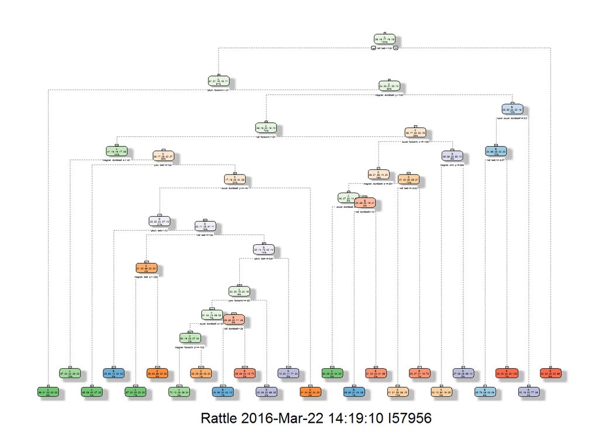

```r
set.seed(12345)
modFitA1 <- rpart(classe ~ ., data=my_Training, method="class")
fancyRpartPlot(modFitA1)
```

```r
predictionsA1 <- predict(modFitA1, my_Testing, type = "class")
cmtree <- confusionMatrix(predictionsA1, my_Testing$classe)
cmtree
```

```
## Confusion Matrix and Statistics
##
##           Reference
## Prediction    A    B    C    D    E
##          A 2008  333   47  157   43
##          B   53  752   69   34   82
##          C   43  292 1166  136  180
##          D   82  101   84  857  105
##          E   46   40    2  102 1032
##
## Overall Statistics
##
##                Accuracy : 0.7411
##                  95% CI : (0.7313, 0.7508)
##     No Information Rate : 0.2845
##     P-Value [Acc > NIR] : < 2.2e-16
##
##                   Kappa : 0.6711
##  Mcnemar's Test P-Value : < 2.2e-16
##
## Statistics by Class:
##
##                      Class: A Class: B Class: C Class: D Class: E
## Sensitivity            0.8996  0.49539   0.8523   0.6664   0.7157
## Specificity            0.8967  0.96239   0.8995   0.9433   0.9703
## Pos Pred Value         0.7759  0.75960   0.6417   0.6973   0.8445
## Neg Pred Value         0.9574  0.88827   0.9665   0.9352   0.9381
## Prevalence             0.2845  0.19347   0.1744   0.1639   0.1838
## Detection Rate         0.2559  0.09585   0.1486   0.1092   0.1315
## Detection Prevalence   0.3298  0.12618   0.2316   0.1566   0.1557
## Balanced Accuracy      0.8982  0.72889   0.8759   0.8049   0.8430
```

```r
# plot(modFitA1)
```

Prediction with Random Forests

```r
set.seed(12345)
modFitB1 <- randomForest(classe ~ ., data=my_Training)
predictionB1 <- predict(modFitB1, my_Testing, type = "class")
cmrf <- confusionMatrix(predictionB1, my_Testing$classe)
cmrf
```

```
## Confusion Matrix and Statistics
##
##           Reference
## Prediction    A    B    C    D    E
##          A 2231   13    0    0    0
##          B    1 1500    9    0    0
##          C    0    5 1358   14    0
##          D    0    0    1 1272    5
##          E    0    0    0    0 1437
##
## Overall Statistics
##
##                Accuracy : 0.9939
##                  95% CI : (0.9919, 0.9955)
##     No Information Rate : 0.2845
##     P-Value [Acc > NIR] : < 2.2e-16
##
##                   Kappa : 0.9923
##  Mcnemar's Test P-Value : NA
##
## Statistics by Class:
##
##                      Class: A Class: B Class: C Class: D Class: E
## Sensitivity            0.9996   0.9881   0.9927   0.9891   0.9965
## Specificity            0.9977   0.9984   0.9971   0.9991   1.0000
## Pos Pred Value         0.9942   0.9934   0.9862   0.9953   1.0000
## Neg Pred Value         0.9998   0.9972   0.9985   0.9979   0.9992
## Prevalence             0.2845   0.1935   0.1744   0.1639   0.1838
## Detection Rate         0.2843   0.1912   0.1731   0.1621   0.1832
## Detection Prevalence   0.2860   0.1925   0.1755   0.1629   0.1832
## Balanced Accuracy      0.9986   0.9933   0.9949   0.9941   0.9983
```

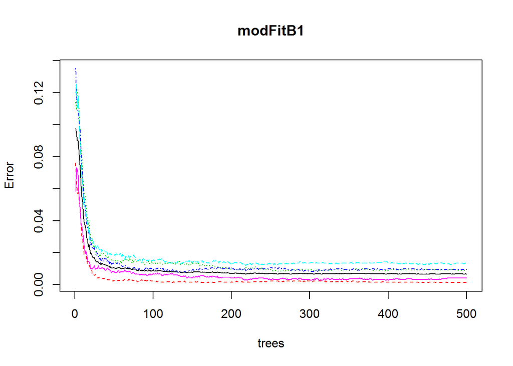

```r
plot(modFitB1)
```

The estimated error rate is less than 1%.

## Predicting Results on the Test Data

Prediction with Random Forests on testing dataset. Get the result for Course project quiz.

```r
predictionB2 <- predict(modFitB1, testing, type = "class")
predictionB2
```

```
##  1  2  3  4  5  6  7  8  9 10 11 12 13 14 15 16 17 18 19 20
##  B  A  B  A  A  E  D  B  A  A  B  C  B  A  E  E  A  B  B  B
## Levels: A B C D E
```

```r
# Write the results to a text file for submission
pml_write_files = function(x){
    n = length(x)
    for(i in 1:n){
        filename = paste0("problem_id_",i,".txt")
        write.table(x[i],file=filename,quote=FALSE,row.names=FALSE,col.names=FALSE)
    }
}
pml_write_files(predictionB2)
```

## CONCLUSION

# Citation

Velloso, E.; Bulling, A.; Gellersen, H.; Ugulino, W.; Fuks, H. Qualitative Activity Recognition of Weight Lifting Exercises. Proceedings of 4th International Conference in Cooperation with SIGCHI (Augmented Human ’13) . Stuttgart, Germany: ACM SIGCHI, 2013.